# Do countries with a higher vaccination rate really have higher excess mortality?

```r
#loading packages and importing data
rm(list=ls())
setwd("C:/Users/jvona/Documents/A Good Reason")
library(tidyverse)
library(data.table)
library(countrycode)
library(ggthemes)
library(zoo)
library(weights)
#import Eurostat excess mortality data
df_exmort_raw <- fread("eurostat excess mortality/demo_mexrt_page_linear.csv")
#import Eurostat mortality data
df_totalmort_raw <- fread("eurostat excess mortality/demo_mmonth_page_linear.csv")
#import OWID data
df_owid_raw <- fread("eurostat excess mortality/owid-covid-data.csv")

#select and rename relevant columns in exmort data
df_exmort <- df_exmort_raw %>%
  select(geo, TIME_PERIOD, OBS_VALUE) %>%
  rename(location=geo, month=TIME_PERIOD, excess_mortality=OBS_VALUE) %>%
  filter(location!="EU27_2020") %>%
  mutate(location=countrycode(location, "eurostat", "cldr.name.en"))

#select and rename relevant columns in total mort data
df_totalmort <- df_totalmort_raw %>%
  select(geo, month, TIME_PERIOD, OBS_VALUE) %>%
  rename(location=geo, year=TIME_PERIOD, total_mortality=OBS_VALUE) %>%
    mutate(location=countrycode(location, "eurostat", "cldr.name.en"),
           month=paste(year,"-",substr(month,2,3), sep="")) %>%
             select(-year)


#select and rename relevant columns
df_owid <- df_owid_raw %>%
  select(location, date, people_fully_vaccinated_per_hundred, total_boosters_per_hundred, excess_mortality_cumulative_per_million, population)
```

This is a short and rough analysis of excess mortality patterns in Europe since 2020. I want to address the question of whether higher vaccination rates were associated with higher or lower excess mortality. The data I am working with here is highly aggregated and shall only be understood as evidence complementary to studies comparing individuals by their vaccination status. The most important limitation is that I only looked at total vaccination rates. Given the age-dependent IFR of Covid-19, even “safe and effective” vaccines could not be expected to have any large effect on reducing under-60 mortality.

I was motivated to make this analysis by this sentence by Thomas Verduyn in his article “Did side effects from the Covid shots cause any excess mortality?” (https://pandata.org/did-side-effects-from-the-covid-shots-cause-any-excess-mortality/): “Three different studies found that all-cause-mortality data for 2022 in Europe reveal a disturbing trend of greater excess mortality in countries with higher vaccination rates.”. Two of the provided references do not actually provide any evidence supporting this claim. Only the preprint by Aarstad and Kvitastein (2023) (https://doi.org/10.20944/preprints202302.0350.v1) actually shows the mentioned relation.

Below we see the distribution of vaccination rates and cumulative excess mortality since 2020, using data from Our World in Data. I included territories for which the latest available cumulative excess mortality is not older than 1 January 2023. For vaccination rates, I chose 1 January 2022 as the latest accepted date to increase the sample size as vaccination rates have not changed substantially in 2022 in most countries. This leaves us with 67 countries in the sample.

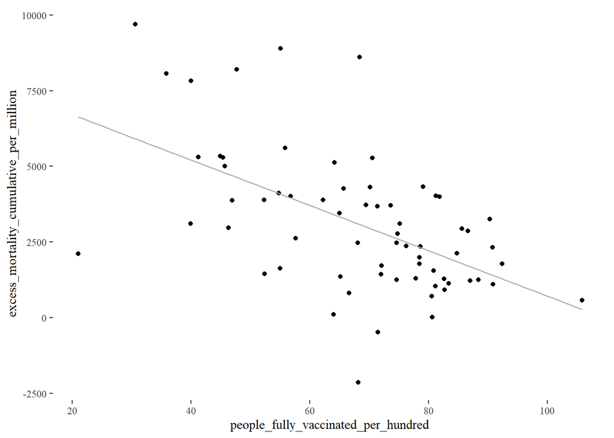

```r
#create dataframe of latest available cumulative excess mortality data as long as it is from this year
df_owid_cumulmort <- df_owid %>%
  group_by(location) %>%
  filter(!is.na(excess_mortality_cumulative_per_million)) %>%
  arrange(desc(date)) %>%
  slice(1) %>%
  filter(date>="2023-01-01") %>%
  ungroup() %>%
  select(location, excess_mortality_cumulative_per_million, population)

#create dataframe of latest available vaccination rates as long as it not older than 1 Jan 2022
df_owid_vaccrate <- df_owid %>%
  group_by(location) %>%
  filter(!is.na(people_fully_vaccinated_per_hundred)) %>%
  arrange(desc(date)) %>%
  slice(1) %>%
  filter(date>="2022-01-01") %>%
  ungroup() %>%
  select(location, people_fully_vaccinated_per_hundred)

#merge with excess mortality data

df_owid_cumul_all <- df_owid_cumulmort %>%
  inner_join(df_owid_vaccrate, by=c("location"))

ggplot(df_owid_cumul_all, aes(people_fully_vaccinated_per_hundred, excess_mortality_cumulative_per_million))+
  theme_tufte()+
  geom_point()+
  geom_smooth(method="lm", se=FALSE, color="dark grey", size=0.5)
```

```r
#correlation coefficient weighted by population size:
#cor(df_owid_cumul_all$people_fully_vaccinated_per_hundred, df_owid_cumul_all$excess_mortality_cumulative_per_million)
#print(wtd.cors(df_owid_cumul_all$people_fully_vaccinated_per_hundred, df_owid_cumul_all$excess_mortality_cumulative_per_million, weight=df_owid_cumul_all$population))
```

Weighted by countries’ population size, the correlation coefficient is -0.58 (it’s -0.55 without weighting). Using only countries with vaccination rates available in 2023, the sample size decreases from 67 to 49, but the coefficients don’t change meaningfully (-0.58 with population weighting, -0.56 without). The picture is similar when looking at booster rates instead of vaccination rates, this time only for data from 1 January 2023 or later, as booster rates likely changed more through 2022. Data on boosters is available for 44 countries. Here, the correlation weighted by population is even -0.69 (-0.56 without weighting).

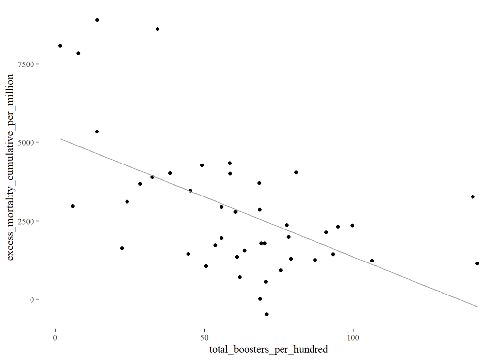

```r
df_owid_boostrate <- df_owid %>%
  group_by(location) %>%
  filter(!is.na(total_boosters_per_hundred)) %>%
  arrange(desc(date)) %>%
  slice(1) %>%
  filter(date>="2023-01-01") %>%
  ungroup() %>%
  select(location, total_boosters_per_hundred)

#merge with excess mortality data

df_owid_cumul_all_boosters <- df_owid_cumulmort %>%
  inner_join(df_owid_boostrate, by=c("location"))


ggplot(df_owid_cumul_all_boosters, aes(total_boosters_per_hundred, excess_mortality_cumulative_per_million))+
  theme_tufte()+
  geom_point()+
  geom_smooth(method="lm", se=FALSE, color="dark grey", size=0.5)
```

```r
#this looks like a negative correlation

#print(cor(df_owid_cumul_all_boosters$total_boosters_per_hundred, df_owid_cumul_all_boosters$excess_mortality_cumulative_per_million))

#weighted by population size:
#cors(df_owid_cumul_all_boosters$total_boosters_per_hundred, df_owid_cumul_all_boosters$excess_mortality_cumulative_per_million)
#print(wtd.cors(df_owid_cumul_all_boosters$total_boosters_per_hundred, df_owid_cumul_all_boosters$excess_mortality_cumulative_per_million, weight=df_owid_cumul_all_boosters$population))
```

As the old saying goes, correlation does not imply causation. There could be some reason for countries with higher vaccination rates to have had lower excess mortality over the three years 2020 to 2022. On the other hand, the fact that excess mortality and vaccination rates are correlated positively in 2022, but negatively in 2020 to 2022 (i.e. in 2020/21) would work well with the hypothesis that the vaccines indeed were effective in preventing deaths in the short run. If that was the case, we should have seen lower mortality in highly vaccinated countries in 2021. A lower mortality in 2021 on the other hand would mean more frail people alive in 2022 who would die then.

A simple graph shows how cautious we must be to derive any premature conclusions. Below, we see the correlation between vaccination rates in 2022/23 and excess mortality in 2020 only.

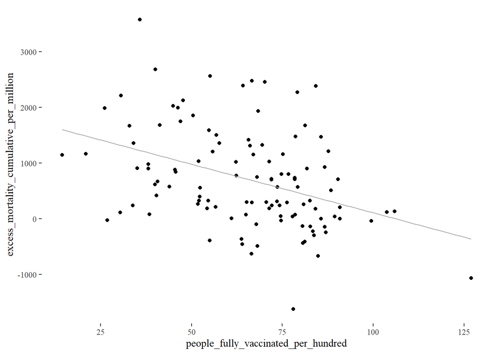

```r
#correlation coefficient between vaccination rates in 2022/23 and excess mortality in 2020
df_owid_cumulmort_2020 <- df_owid %>%
  group_by(location) %>%
  filter(!is.na(excess_mortality_cumulative_per_million)) %>%
  arrange(desc(date)) %>%
  filter(date<="2021-01-01"&date>="2020-12-15") %>%
  slice(1) %>%
  ungroup() %>%
  select(location, excess_mortality_cumulative_per_million, population)

df_owid_cumul_all_2020 <- df_owid_cumulmort_2020 %>%
  inner_join(df_owid_vaccrate, by=c("location"))

ggplot(df_owid_cumul_all_2020, aes(people_fully_vaccinated_per_hundred, excess_mortality_cumulative_per_million))+
  theme_tufte()+
  geom_point()+
  geom_smooth(method="lm", se=FALSE, color="dark grey", size=0.5)
```

```r
#cor(df_owid_cumul_all_2020$people_fully_vaccinated_per_hundred, df_owid_cumul_all_2020$excess_mortality_cumulative_per_million)
#print(wtd.cors(df_owid_cumul_all_2020$people_fully_vaccinated_per_hundred, df_owid_cumul_all_2020$excess_mortality_cumulative_per_million, weight=df_owid_cumul_all_2020$population))
```

I wanted to test a bit more the hypothesis that the positive correlation between 2022 mortality and vaccination rates is due to lower 2020/21 mortality in highly vaccinated places (even if not causal).

Note that this is related to Aarstad and Kvitastein (2023) to some degree, using a longer time horizon, but less scrutiny regarding controls. As they did, I use Eurostat data for 30 European countries (27 EU countries plus Iceland, Norway and Switzerland). I excluded Liechtenstein, Luxembourg, and Switzerland, as no up-to-date vaccination rates were available. The first two don’t make any difference when weighting by population anyway.

First, I checked how the relationship between vaccination rates and excess mortality changed over time. Excess mortality rates from Eurostat are provided by country per month. Calculating cumulative excess mortality rates over different periods (e.g. only since January 2021 or only for 2022) requires knowing at least two of these three: excess mortality, actual mortality, expected mortality. In the dataset I used, actual mortality figures were provided, so I could use these to calculate cumulative excess mortality. I calculated cumulative excess mortality since 2020 as well as since 2021. From October 2022 onwards, data on total mortality is missing for several countries. From this point on, I used a more rough estimate for the cumulative excess mortality. I took the weighted average of the last available number (weighted by the months it was available, e.g. 32 months from Jan 2020 to Oct 2022) and the mean of the monthly excess mortality rates for the remaining months.

For example, when total mortality data for a country was available until October 2022, the cumulative excess mortality in March 2023 would be estimated as:

(32/36) * [(sum(total mortality jan 20 to oct 22) - sum(expected mortality jan 20 to oct 20)]/[sum(expected mortality jan 20 to oct 20)] * 100 + (4/36) * mean(excess mortality nov 22 to feb 23)

I calculated the expected mortality for each month as the total mortality divided by 1 plus excess mortality.

Example: excess mortality = 5% = 0.05, expected mortality = 1000, total mortality = 1050 -> 1000 = 1050/(1+0.05)

Aarstad and Kvitastein calculated the whole excess mortality themselves, the same way as Eurostat apparently does it, by taking the average mortality for each calendar month from 2016 to 2019. Maybe I should have done this. It would probably have been easier, and would also allow for better comparison with their paper. But I only read that paper after I already went through these calculations.

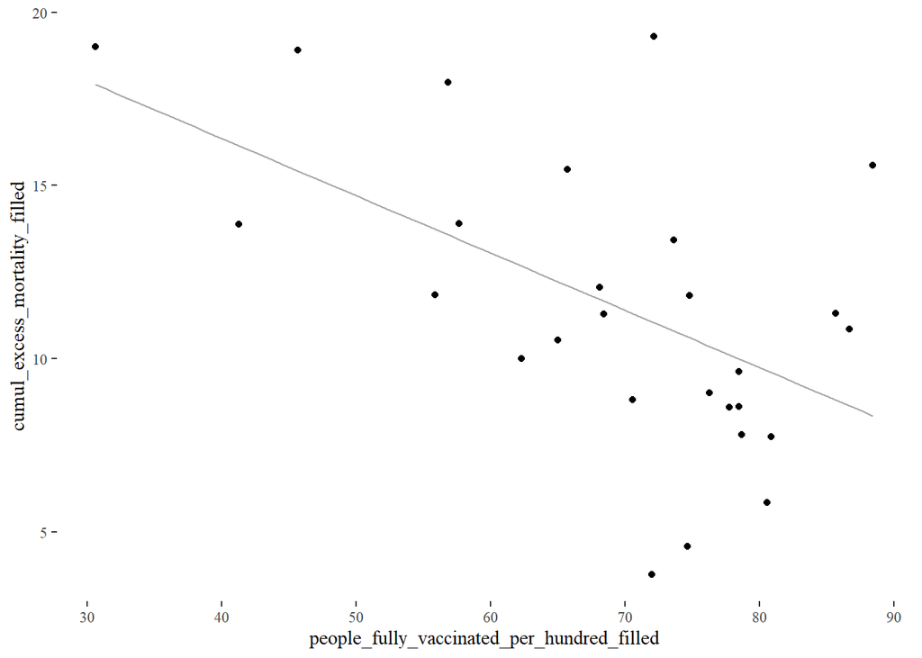

```r
#calculate monthly means for vaccination rates
df_owid_monthly <- df_owid %>%
  mutate(month=substr(date,1,7)) %>%
  select(location, month, people_fully_vaccinated_per_hundred, total_boosters_per_hundred, population) %>%
  group_by(month, location) %>%
  mutate(people_fully_vaccinated_per_hundred=mean(people_fully_vaccinated_per_hundred, na.rm=TRUE),
         total_boosters_per_hundred=mean(total_boosters_per_hundred, na.rm=TRUE)) %>%
  unique()

#merge data
df_merged <- df_owid_monthly %>%
  right_join(df_exmort, by=c("location", "month")) %>%   full_join(df_totalmort, by=c("location", "month"))

df_merged$month <- as.yearmon(df_merged$month)

#calculate expected mortality from actual mortality and excess mortality
df_merged <- df_merged %>%
  mutate(expected_mortality=total_mortality/((excess_mortality/100)+1))

#calculate cumulative excess mortality before each month
df_merged <- df_merged %>%
  group_by(location) %>%
  mutate(
    cumul_excess_mortality = cumsum(lag(total_mortality, default = 0) - lag(expected_mortality, default = 0)) / (cumsum(lag(expected_mortality, default = 0))) * 100)

#calculate cumulative excess mortality before each month, starting with January 2021
df_merged_from21 <- df_merged %>%
  group_by(location) %>%
  filter(month>="2021-01") %>%
  mutate(
    cumul_excess_mortality = cumsum(lag(total_mortality, default = 0) - lag(expected_mortality, default = 0)) / (cumsum(lag(expected_mortality, default = 0))) * 100)

#replace cumulative excess mortality with 0 for Jan 2020 / Jan 2021
df_merged$cumul_excess_mortality[df_merged$month=="2020-01"] <- 0
df_merged_from21$cumul_excess_mortality[df_merged_from21$month=="2021-01"] <- 0

# Find the latest available cumul_excess_mortality

df_merged_filled <- df_merged %>%
  group_by(location) %>%
  mutate(
    n1 = year(month) * 12 + month(month) - (year(as.yearmon("2020-01")) * 12 + month(as.yearmon("2020-01"))) + 1,
    n2 = sum(!is.na(cumul_excess_mortality)),
    n3 = n1 - n2,
    mean_exmort_sinceNA = ifelse(n1<=n2, NA, ifelse(n1==n2+1, lag(excess_mortality),lead(cummean(excess_mortality[n1 >= n2])))),
    cumul_excess_mortality_filled = ifelse(is.na(cumul_excess_mortality), (n2/n1) * tail(na.omit(cumul_excess_mortality), 1) + (n3/n1)* mean_exmort_sinceNA, cumul_excess_mortality)) %>%
  fill(cumul_excess_mortality_filled, .direction = "down")


df_merged_from21_filled <- df_merged_from21 %>%
  group_by(location) %>%
  mutate(
    n1 = year(month) * 12 + month(month) - (year(as.yearmon("2021-01")) * 12 + month(as.yearmon("2021-01"))) + 1,
    n2 = sum(!is.na(cumul_excess_mortality)),
    n3 = n1 - n2,
    mean_exmort_sinceNA = ifelse(n1<=n2, NA, ifelse(n1==n2+1, lag(excess_mortality),lead(cummean(excess_mortality[n1 >= n2])))),
    cumul_excess_mortality_filled = ifelse(is.na(cumul_excess_mortality), (n2/n1) * tail(na.omit(cumul_excess_mortality), 1) + (n3/n1)* mean_exmort_sinceNA, cumul_excess_mortality)) %>%
  fill(cumul_excess_mortality_filled, .direction = "down")

#also fill vaccination rates with the latest available option if it is at least from 2022, this is the case for all countries except Liechtenstein, Luxembourg, Switzerland

df_merged_filled <- df_merged_filled %>%
  group_by(location) %>%
  mutate(people_fully_vaccinated_per_hundred_filled=people_fully_vaccinated_per_hundred) %>%
  fill(people_fully_vaccinated_per_hundred_filled, .direction = "down") %>%
  filter(!location %in% c("Liechtenstein", "Luxembourg", "Switzerland"))

df_merged_from21_filled <- df_merged_from21_filled %>%
  group_by(location) %>%
  mutate(people_fully_vaccinated_per_hundred_filled=people_fully_vaccinated_per_hundred) %>%
  fill(people_fully_vaccinated_per_hundred_filled, .direction = "down") %>%
  filter(!location %in% c("Liechtenstein", "Luxembourg", "Switzerland"))

df_cumul <- df_merged_filled %>%
  filter(month=="Apr 2023")

ggplot(df_cumul, aes(people_fully_vaccinated_per_hundred_filled, cumul_excess_mortality_filled))+
  theme_tufte()+
  geom_point()+
  geom_smooth(method="lm", se=FALSE, color="dark grey", size=0.5)
```

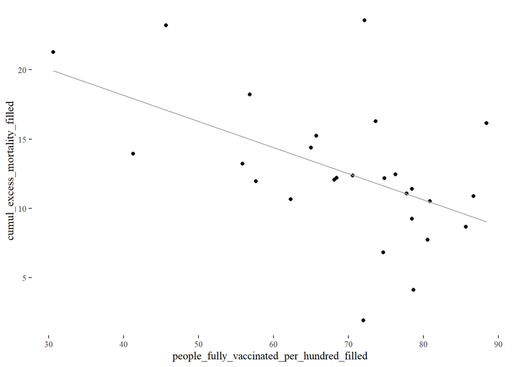

```r
#this looks like a negative correlation, too

#print(cor(df_cumul$people_fully_vaccinated_per_hundred_filled, df_cumul$cumul_excess_mortality_filled))

#print(wtd.cors(df_cumul$people_fully_vaccinated_per_hundred_filled, df_cumul$cumul_excess_mortality_filled, weight=df_cumul$population))

df_cumul_from21 <- df_merged_from21_filled %>%
  filter(month=="Apr 2023")

ggplot(df_cumul_from21, aes(people_fully_vaccinated_per_hundred_filled, cumul_excess_mortality_filled))+
  theme_tufte()+
  geom_point()+
  geom_smooth(method="lm", se=FALSE, color="dark grey", size=0.5)
```

```r
#this looks like a negative correlation, too

#print(cor(df_cumul_from21$people_fully_vaccinated_per_hundred_filled, df_cumul_from21$cumul_excess_mortality_filled))

#print(wtd.cors(df_cumul_from21$people_fully_vaccinated_per_hundred_filled, df_cumul_from21$cumul_excess_mortality_filled, weight=df_cumul_from21$population))
```

The plots show the correlation between vaccination rates and excess mortality between January 2020 and April 2023 or January 2021 and April 2023, respectively, using the Eurostat data. Correlation coefficients weighted by population are -0.66 (unweighted -0.54) for the longer time frame and -0.67 (unweighted -0.52) for the shorter one. I think this is an interesting finding to keep in mind, whatever one thinks about the drivers of excess mortality. The positive correlation between excess mortality in 2022/23 and vaccine uptake should certainly ring alarm bells. Yet, looking at the entire time since the start of vaccination campaigns (roughly coinciding with the beginning of 2021), more vaccinated countries had a lower mortality rate.

In the following, I want to assess how the correlation between vaccination rates and monthly excess mortality changed over time. Remember that these plots say little about the immediate effects of vaccinations as the variable used here is the number of people who are “fully vaccinated”, not new vaccinations.

First, we see the monthly correlation coefficient of vaccination rate and excess mortality since January 2021, weighted by population.

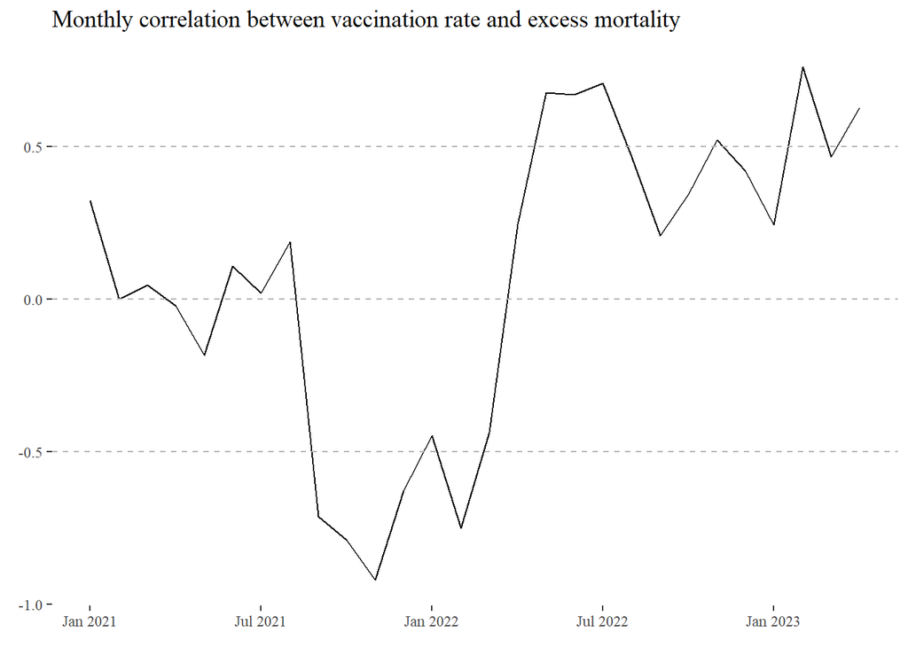

```r
df_merged_monthlycor1 <- df_merged_filled %>%
  filter(month >= "Jan 2021") %>%
  group_by(month) %>%
  filter(!is.na(people_fully_vaccinated_per_hundred_filled)) %>%
  mutate(corr=cor(excess_mortality, people_fully_vaccinated_per_hundred_filled),
         weightedcorr=wtd.cors(excess_mortality, people_fully_vaccinated_per_hundred_filled, weight=population))

df_merged_monthlycor2 <- df_merged_filled %>%
  filter(month >= "Jan 2021") %>%
  group_by(month) %>%
  mutate(corr=cor(excess_mortality, cumul_excess_mortality_filled),
         weightedcorr=wtd.cors(excess_mortality, cumul_excess_mortality_filled, weight=population))



ggplot(df_merged_monthlycor1, aes(month, weightedcorr))+
  theme_tufte()+
  geom_line()+
  labs(x=element_blank(), y=element_blank(), title="Monthly correlation between vaccination rate and excess mortality")+
  geom_hline(yintercept = c(-0.5, 0, 0.5), linetype = "dashed", color = "gray70", size = 0.5)
```

But remember, over the whole time, vaccination rates are still associated with lower mortality, not higher. Could it be that this is simply because countries which saw fewer people die in 2020 and 2021 had more people left to die in 2022? In the following, we see the correlation between monthly excess mortality and cumulative excess mortality since January 2020.

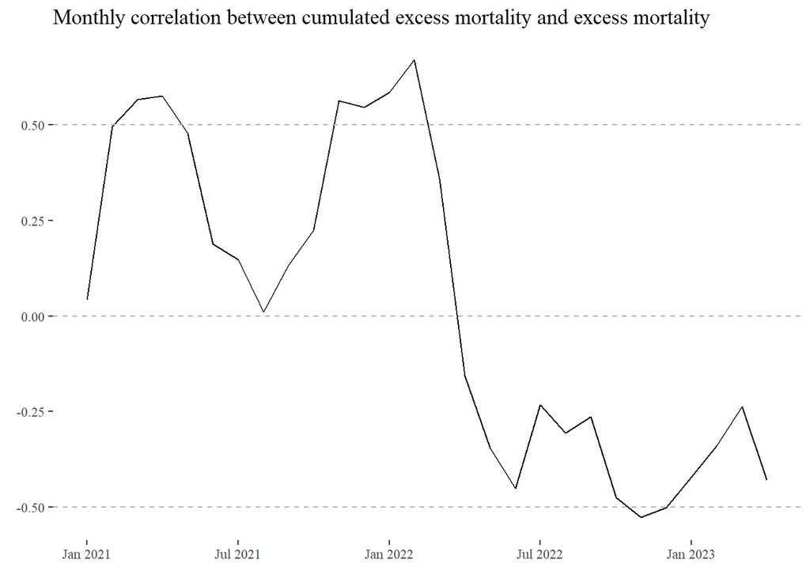

```r
ggplot(df_merged_monthlycor2, aes(month, weightedcorr))+
  theme_tufte()+
  geom_line()+
  labs(x=element_blank(), y=element_blank(), title="Monthly correlation between cumulated excess mortality and excess mortality")+
  geom_hline(yintercept = c(-0.5, 0, 0.5), linetype = "dashed", color = "gray70", size = 0.5)
```

As expected, this coefficient becomes more negative over time. When the correlation between vaccination and excess mortality is negative, this coefficient for cumulated excess mortality is unexpectedly positive. This time definitely deserves further analysis.

```r
#create dataframe with cumulative excess mortality since January 2022 as above
df_merged_from22 <- df_merged %>%
  group_by(location) %>%
  filter(month>="2022-01") %>%
  mutate(
    cumul_excess_mortality = cumsum(lag(total_mortality, default = 0) - lag(expected_mortality, default = 0)) / (cumsum(lag(expected_mortality, default = 0))) * 100)

df_merged_from22_filled <- df_merged_from22 %>%
  mutate(
    n1 = year(month) * 12 + month(month) - (year(as.yearmon("2022-01")) * 12 + month(as.yearmon("2022-01"))) + 1,
    n2 = sum(!is.na(cumul_excess_mortality)),
    n3 = n1 - n2,
    mean_exmort_sinceNA = ifelse(n1<=n2, NA, ifelse(n1==n2+1, lag(excess_mortality),lead(cummean(excess_mortality[n1 >= n2])))),
    cumul_excess_mortality_filled = ifelse(is.na(cumul_excess_mortality), (n2/n1) * tail(na.omit(cumul_excess_mortality), 1) + (n3/n1)* mean_exmort_sinceNA, cumul_excess_mortality)) %>%
  fill(cumul_excess_mortality_filled, .direction = "down") %>%
  mutate(excess_mortality_2022=cumul_excess_mortality_filled[month=="2023-01"],
         excess_mortality_2022andjanfeb=cumul_excess_mortality_filled[month=="2023-03"]) %>%
  select(location, excess_mortality_2022, excess_mortality_2022andjanfeb) %>%
  unique()

#merge with data for excess mortality and vaccination rates at the end of 2021
df_regression <- df_merged_filled %>%
  mutate(excess_mortality202021=cumul_excess_mortality_filled[month=="2022-01"],
         vaccinationrate_dec21=people_fully_vaccinated_per_hundred_filled[month=="2022-01"]) %>%
  select(location, excess_mortality202021,vaccinationrate_dec21) %>%
  unique() %>%
  full_join(df_merged_from22_filled, by=c("location")) %>%
  filter(!is.na(vaccinationrate_dec21))

#include plots over time

regression_model <- lm(excess_mortality_2022~excess_mortality202021+vaccinationrate_dec21, df_regression)
regression_model2 <- lm(excess_mortality_2022andjanfeb~excess_mortality202021+vaccinationrate_dec21, df_regression)

print(summary(regression_model))
```

```
##
## Call:
## lm(formula = excess_mortality_2022 ~ excess_mortality202021 +
##     vaccinationrate_dec21, data = df_regression)
##
## Residuals:
##     Min      1Q  Median      3Q     Max
## -6.9667 -4.0637  0.1138  2.8187 13.2755
##
## Coefficients:
##                        Estimate Std. Error t value Pr(>|t|)
## (Intercept)             -3.9870     9.2611  -0.431   0.6705
## excess_mortality202021   0.1793     0.2115   0.848   0.4045
## vaccinationrate_dec21    0.1933     0.1059   1.826   0.0798 .
## ---
## Signif. codes:  0 '***' 0.001 '**' 0.01 '*' 0.05 '.' 0.1 ' ' 1
##
## Residual standard error: 4.945 on 25 degrees of freedom
## Multiple R-squared:  0.1329, Adjusted R-squared:  0.06354
## F-statistic: 1.916 on 2 and 25 DF,  p-value: 0.1682
```

```r
print(summary(regression_model2))
```

```
##
## Call:
## lm(formula = excess_mortality_2022andjanfeb ~ excess_mortality202021 +
##     vaccinationrate_dec21, data = df_regression)
##
## Residuals:
##     Min      1Q  Median      3Q     Max
## -6.8328 -3.4781  0.4714  2.4515 13.2096
##
## Coefficients:
##                        Estimate Std. Error t value Pr(>|t|)
## (Intercept)            -5.33471    8.65566  -0.616   0.5433
## excess_mortality202021  0.14825    0.19764   0.750   0.4602
## vaccinationrate_dec21   0.20714    0.09894   2.094   0.0466 *
## ---
## Signif. codes:  0 '***' 0.001 '**' 0.01 '*' 0.05 '.' 0.1 ' ' 1
##
## Residual standard error: 4.622 on 25 degrees of freedom
## Multiple R-squared:  0.1848, Adjusted R-squared:  0.1195
## F-statistic: 2.833 on 2 and 25 DF,  p-value: 0.07781
```

If anything, these results are evidence against the hypothesis that 2022 mortality could be explained by 2020/21 mortality. The coefficient of 2020/21 excess mortality on 2022 excess mortality is positive and insignificant. In the second model, a 1 percentage point increase in the vaccination rate is associated with an average increase in excess mortality of 0.2 percentage points. This result is significant at the 5 percent level. However, the low R-squared shows that this simple model can only explain a relatively small part of the total variation.